# Linear regression tutorial

Arthur Mello

Regression techniques help you measure the extent to which variables are related. They allow you to say, for instance, that “for each square meter in a house, it will cost an extra $6,000” (in this case those variables are house area and its price).

A linear regression is the type of regression we do when that relationship is linear. In our example, it is probably the case: extra squared meters will always add more or less the same to the house price. Now let’s think of house price per number of bathrooms: although adding a second bathroom to your house will increase a its house price, it is very unlikely that the 12th bathroom will make much difference to a house that already has 11 of them.

In regression techniques we always have our target numeric variable (Y) and our explanatory variables (X1, X2, …. ). In this case, since we are trying to explain house price, that’s our Y. In the first example, our X was the house area and, in the second one, its number of bathrooms. We also might have multiple X (for instance, if we take area, number of bathrooms and year of the last renovation). Now let’s do our first regression, using R. We will work on a public dataset with data from house sales in King County, USA, available [here](https://www.kaggle.com/harlfoxem/housesalesprediction/downloads/housesalesprediction.zip/1). We can then load it, and take a look at the variables:

```r
# Loading our data
data = read.csv('data/kc_house_data.csv')

# Taking a look at the column names
colnames(data)
```

```
##  [1] "id"            "date"          "price"         "bedrooms"
##  [5] "bathrooms"     "sqft_living"   "sqft_lot"      "floors"
##  [9] "waterfront"    "view"          "condition"     "grade"
## [13] "sqft_above"    "sqft_basement" "yr_built"      "yr_renovated"
## [17] "zipcode"       "lat"           "long"          "sqft_living15"
## [21] "sqft_lot15"
```

So here we have *price* and *sqft_living* (the living area in square feet). Let’s take a look at these two variables behave together:

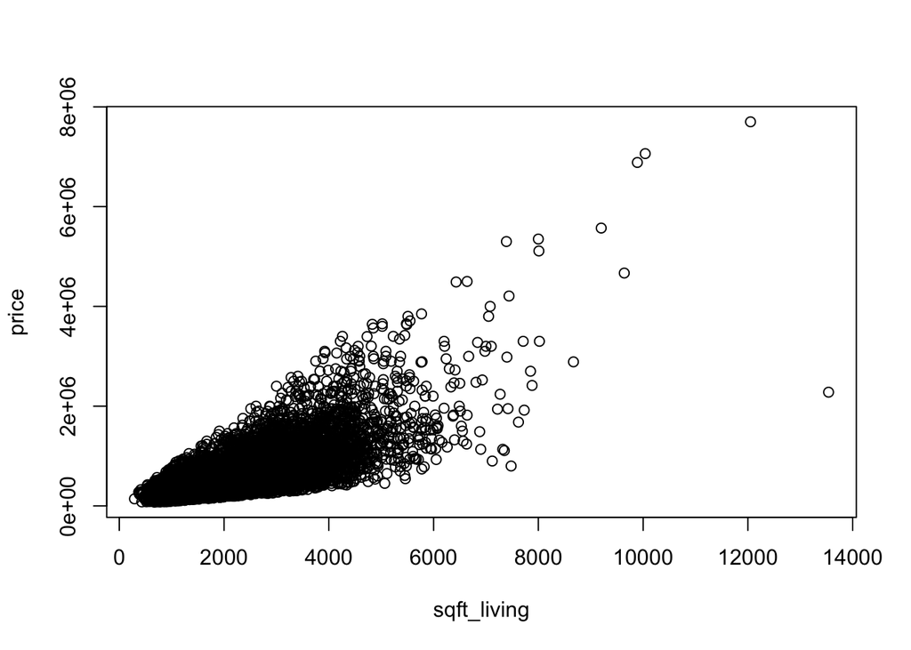

```r
# Attaching it means we can access column names directly, without referring to the data frame
attach(data)

# Plotting price against house area
plot(sqft_living, price)
```

Here we have a scatterplot, where each dot represents a house, with its area in the X axis and its price in the Y axis. As expected, it looks like the bigger the house, the more expensive it is. Also, that relationship looks more or less linear. Our first linear regression equation will look like this:

Y = a + b*X

where **Y** is the house price (price), **X** is its area (sqft_living), **a** is a baseline value, a minimum price for a house, no matter how small it is, and **b** is the coefficient that explains the relationship between the two variables (“for each square meter in a house, it will cost an extra $**b**”). Let’s build our first linear model:

```r
# Creating our first model using these two variables, and analysing it
model1 = lm(price ~ sqft_living, data = data)
summary(model1)
```

```
##
## Call:
## lm(formula = price ~ sqft_living, data = data)
##
## Residuals:
##      Min       1Q   Median       3Q      Max
## -1476062  -147486   -24043   106182  4362067
##
## Coefficients:
##               Estimate Std. Error t value Pr(>|t|)
## (Intercept) -43580.743   4402.690  -9.899   <2e-16 ***
## sqft_living    280.624      1.936 144.920   <2e-16 ***
## ---
## Signif. codes:  0 '***' 0.001 '**' 0.01 '*' 0.05 '.' 0.1 ' ' 1
##
## Residual standard error: 261500 on 21611 degrees of freedom
## Multiple R-squared:  0.4929, Adjusted R-squared:  0.4928
## F-statistic: 2.1e+04 on 1 and 21611 DF,  p-value: < 2.2e-16
```

The lm() function is what allows us to build the model, whereas the summary() function allows us to see what the model yields. Now let’s try to interpret those results:

**Residuals**: it shows the distribution of the residuals, which are the differences between the prices estimated by the model and the actual observed prices. Obviously, we want our estimations to be as close as possible to the real values, which means really small residuals. Ideally, they would be very close to zero, and symmetrically distributed.

**Coefficients**: the field “Estimate” gives us the a and the b from our model, where “intercept” is the a and “sqft_living” is the b (in our example, each square foot of living area means an extra $ 280 in the house price). The other relevant field is “Pr(>|t|)”, which gives us the respective p-values. Roughly speaking, the p-value means how confident we can be about the coefficients estimated. A p-value of 5% means we have 95% confidence in our results. Therefore, the smaller the p-value, the better. Usually, if it’s smaller than 5% or 1%, it’s satisfactory. In our example, the p-values are much smaller than that, so we can consider our coefficients as significant.

**R-squared**: it tells us how much of the variation of the target variable (price) is explained by our model, from 0 to 1. Obviously, the more the better. There’s a caveat, however: when we consider more than one explanatory variable, we should look at the adjusted r-squared. In our example, it’s around 0.49, meaning that our model explains roughly half of the variance in house prices. Let’s look at the line produced by this model:

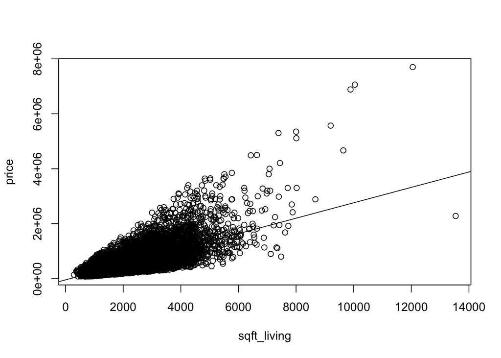

```r
# Adding the regression line to our plot
plot(sqft_living, price)
abline(model1)
```

That line shows, for any given house area, its estimated price according to our model. It doesn’t look very impressive, right? Now that we know how to read our model summary, let’s try to improve it. We can try adding more variables, like the number of bathrooms, for example:

```r
# Trying a second model
model2 = lm(price ~ sqft_living + bathrooms, data = data)
summary(model2)
```

```
##
## Call:
## lm(formula = price ~ sqft_living + bathrooms, data = data)
##
## Residuals:
##      Min       1Q   Median       3Q      Max
## -1483123  -147387   -24190   105951  4359876
##
## Coefficients:
##               Estimate Std. Error t value Pr(>|t|)
## (Intercept) -39456.614   5223.129  -7.554 4.38e-14 ***
## sqft_living    283.892      2.951  96.194  < 2e-16 ***
## bathrooms    -5164.600   3519.452  -1.467    0.142
## ---
## Signif. codes:  0 '***' 0.001 '**' 0.01 '*' 0.05 '.' 0.1 ' ' 1
##
## Residual standard error: 261400 on 21610 degrees of freedom
## Multiple R-squared:  0.4929, Adjusted R-squared:  0.4929
## F-statistic: 1.05e+04 on 2 and 21610 DF,  p-value: < 2.2e-16
```

As we can see, the adjusted R-squared remains virtually the same and the p-value for the bathrooms coefficient is too big, meaning that this variable doesn’t seem significant to explain house prices. Let’s then try a third model, removing bathrooms, and adding other variables that might be relevant:

```r
# Our final model
model3 = lm(price ~ sqft_living + floors + yr_built, data = data)
summary(model3)
```

```
##
## Call:
## lm(formula = price ~ sqft_living + floors + yr_built, data = data)
##
## Residuals:
##      Min       1Q   Median       3Q      Max
## -1669759  -134816   -16331   102089  4092350
##
## Coefficients:
##               Estimate Std. Error t value Pr(>|t|)
## (Intercept)  5.595e+06  1.304e+05   42.92   <2e-16 ***
## sqft_living  2.948e+02  2.018e+00  146.10   <2e-16 ***
## floors       7.517e+04  3.731e+03   20.15   <2e-16 ***
## yr_built    -2.933e+03  6.767e+01  -43.35   <2e-16 ***
## ---
## Signif. codes:  0 '***' 0.001 '**' 0.01 '*' 0.05 '.' 0.1 ' ' 1
##
## Residual standard error: 250800 on 21609 degrees of freedom
## Multiple R-squared:  0.5335, Adjusted R-squared:  0.5334
## F-statistic:  8237 on 3 and 21609 DF,  p-value: < 2.2e-16
```

This time, we improved our adjusted R-squared to 0.53 and all of our coefficients are relevant. Notice that the coefficient for sqft_living has changed: it is now around 294. The coefficient for yr_built is also interesting to look at, since it’s negative. This means that the bigger the value for yr_built that is, the newer the house, the less it costs. In other words, older houses tend to be more expensive. Ok, so what’s next? How can we use this model? Well, we can use it to estimate the sale price for a new house, that is not in our database:

```r
# Trying a prediction
new_house = data.frame(
  sqft_living = 2080, floors = 1, yr_built = 1997
  )
predict(model3,newdata = new_house)
```

```
##        1
## 426715.9
```

So, for a house built in 1997, with 2,080 square feet of living space and one floor, we expect it to cost around $ 426,716. So we have learned how to create a linear model, how to evaluate and improve it, and how to use it for predictions. There are still many improvement opportunities for our model which we’ll address in our next linear regression tutorial, such as fixing heteroskedasticity (I swear this is still English) and multicolinearity but now we have a basic understanding on how these models work, and how to work with them.

**Digging deeper**

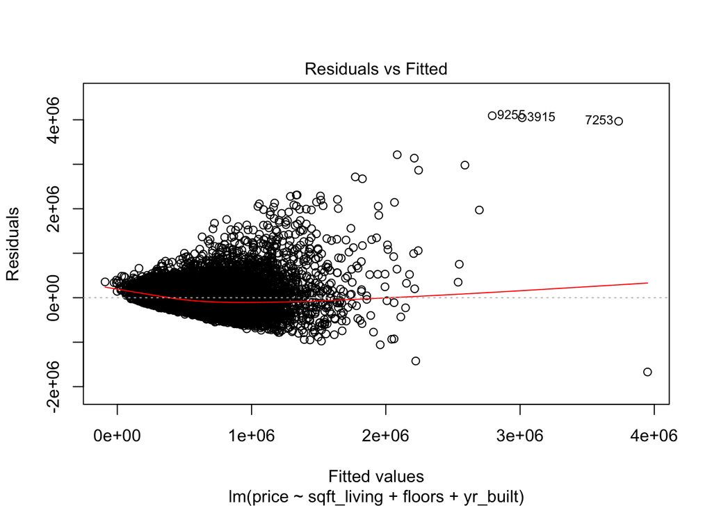

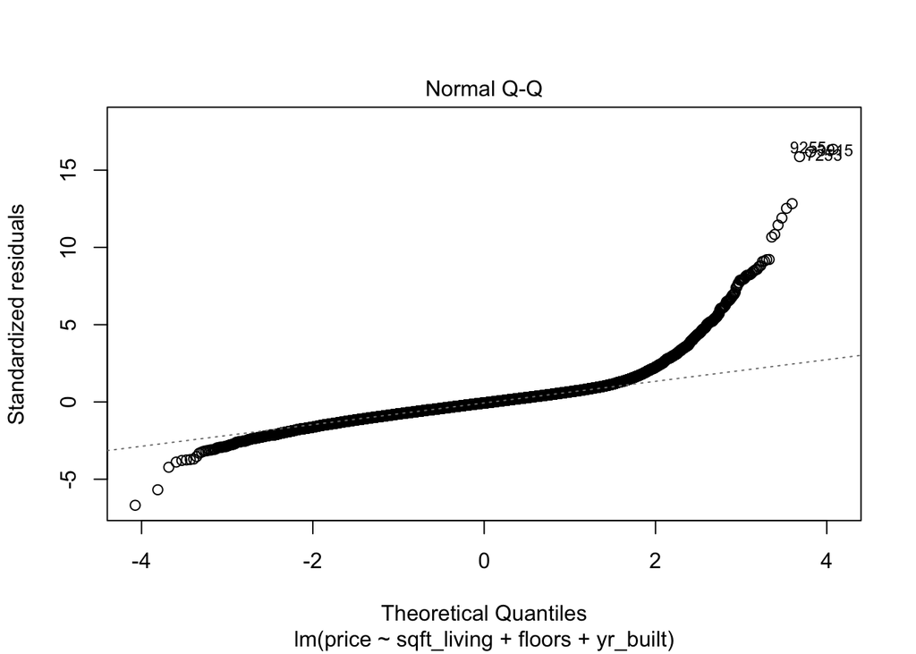

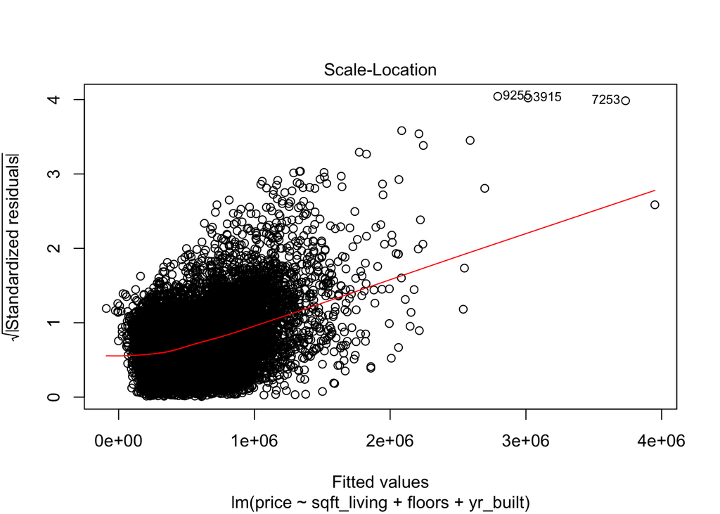

```r
# Looking at the regression plots
plot(model3)
```

```r
# Breusch-Pagan test
library(lmtest)
```

[figure not shown]

```r
bptest(model3)
```

```
##
##  studentized Breusch-Pagan test
##
## data:  model3
## BP = 2633.3, df = 3, p-value < 2.2e-16
```

```r
# Robust regression
library(robust)
model4 = lmRob(price ~ sqft_living + floors + yr_built, data = data)
summary(model4)
```

```
##
## Call:
## lmRob(formula = price ~ sqft_living + floors + yr_built, data = data)
##
## Residuals:
##     Min      1Q  Median      3Q     Max
## -794793  -99349    6057  122207 5111794
##
## Coefficients:
##               Estimate Std. Error t value Pr(>|t|)
## (Intercept)  4.033e+06  9.036e+04   44.64   <2e-16 ***
## sqft_living  1.895e+02  1.556e+00  121.83   <2e-16 ***
## floors       7.777e+04  2.548e+03   30.53   <2e-16 ***
## yr_built    -2.054e+03  4.699e+01  -43.72   <2e-16 ***
## ---
## Signif. codes:  0 '***' 0.001 '**' 0.01 '*' 0.05 '.' 0.1 ' ' 1
##
## Residual standard error: 162500 on 21609 degrees of freedom
## Multiple R-Squared: 0.317
##
## Test for Bias:
##             statistic p-value
## M-estimate      161.7       0
## LS-estimate    4830.0       0
```

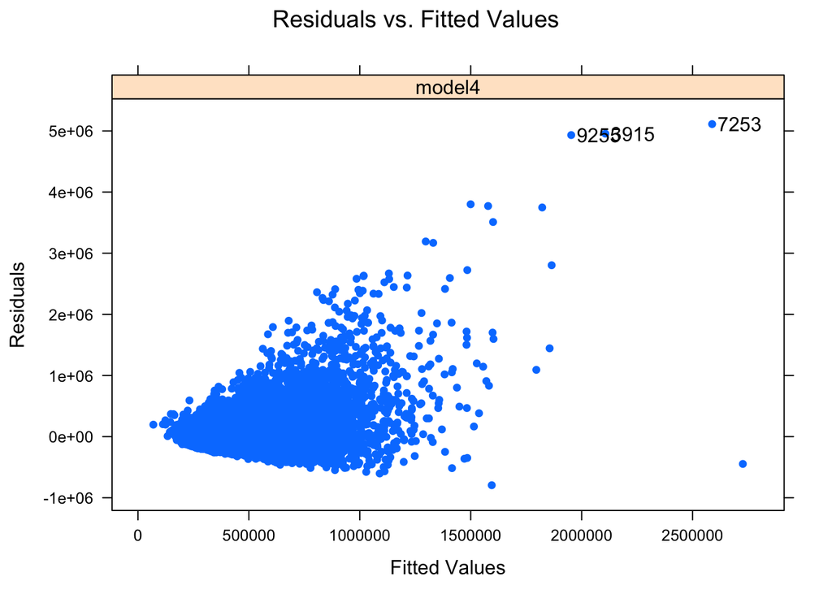

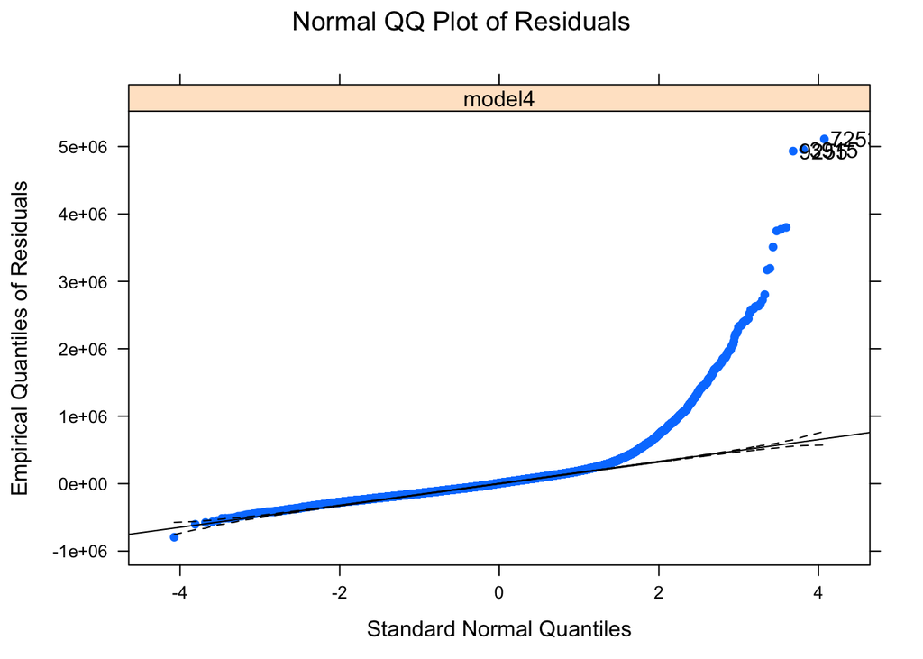

```
## Error in .MCDsingularityMsg(ans$singularity, ans$n.obs): illegal 'singularity$kind'
```

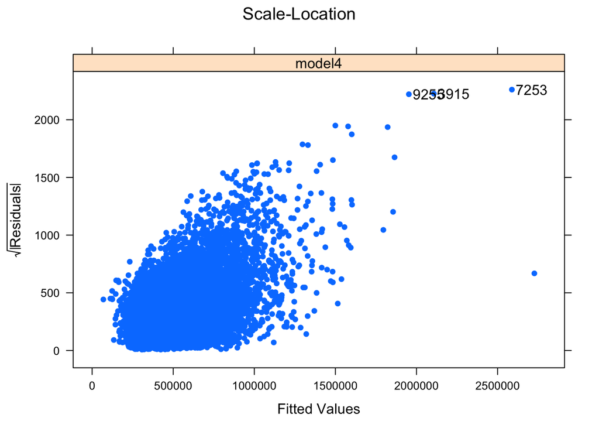

```r
plot(model4)
```

```r
# Multicolinearity
library(car)
vif(model3)
```

```
## sqft_living      floors    yr_built
##    1.180454    1.395073    1.357629
```

```r
# AIC
AIC(model1, model2, model3)
```

|  | df | AIC |
| --- | --- | --- |
| model1 | 3 | 600540.6 |
| model2 | 4 | 600540.4 |
| model3 | 5 | 598739.3 |

**The final frontier**

```r
# Polynomial regression
data$yr_built_2 = data$yr_built^2
model5 = lm(price ~ sqft_living + floors + yr_built + yr_built_2 , data = data)
summary(model5)
```

```
##
## Call:
## lm(formula = price ~ sqft_living + floors + yr_built + yr_built_2,
##     data = data)
##
## Residuals:
##      Min       1Q   Median       3Q      Max
## -1657894  -134994   -15973   101587  4087385
##
## Coefficients:
##               Estimate Std. Error t value Pr(>|t|)
## (Intercept)  6.208e+07  8.482e+06   7.319 2.59e-13 ***
## sqft_living  2.951e+02  2.016e+00 146.347  < 2e-16 ***
## floors       5.977e+04  4.387e+03  13.626  < 2e-16 ***
## yr_built    -6.058e+04  8.656e+03  -6.999 2.66e-12 ***
## yr_built_2   1.471e+01  2.209e+00   6.660 2.81e-11 ***
## ---
## Signif. codes:  0 '***' 0.001 '**' 0.01 '*' 0.05 '.' 0.1 ' ' 1
##
## Residual standard error: 250500 on 21608 degrees of freedom
## Multiple R-squared:  0.5344, Adjusted R-squared:  0.5344
## F-statistic:  6201 on 4 and 21608 DF,  p-value: < 2.2e-16
```

```r
# Ridge regression
library(glmnet)
library(tidyverse)
```

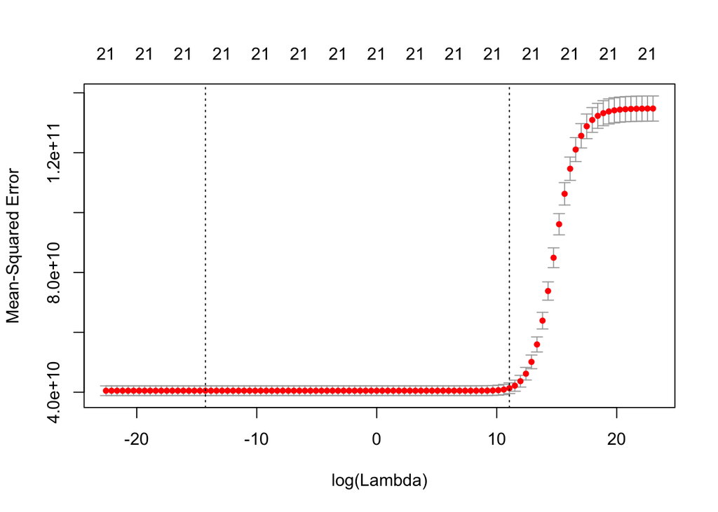

```r
y = data$price
x = data[, names(data) != "price"] %>% data.matrix()

model6 = glmnet(x, y, alpha = 0)

lambdas = 10^seq(10, -10, by = -.2)
cv_fit = cv.glmnet(x, y, alpha = 0, lambda = lambdas)
plot(cv_fit)
```

```r
opt_lambda = cv_fit$lambda.min
opt_lambda
```

```
## [1] 6.309573e-07
```

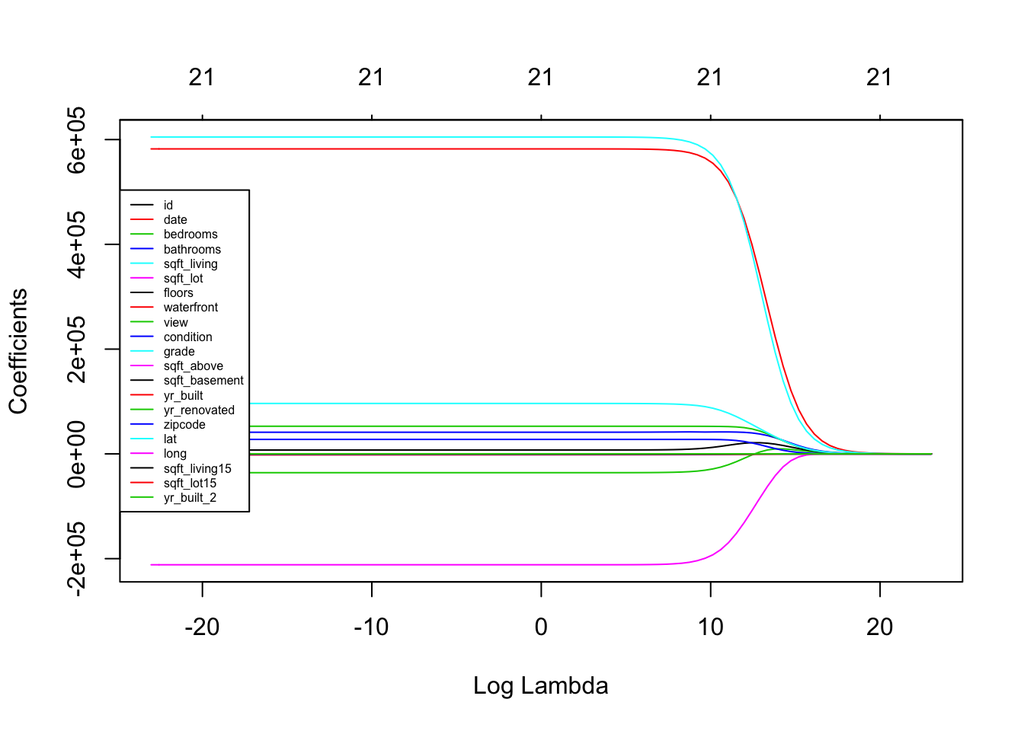

```r
model6 = cv_fit$glmnet.fit
plot(model6, xvar = "lambda")
legend("left", lwd = 1, col = 1:6, legend = colnames(x), cex = .5)
```

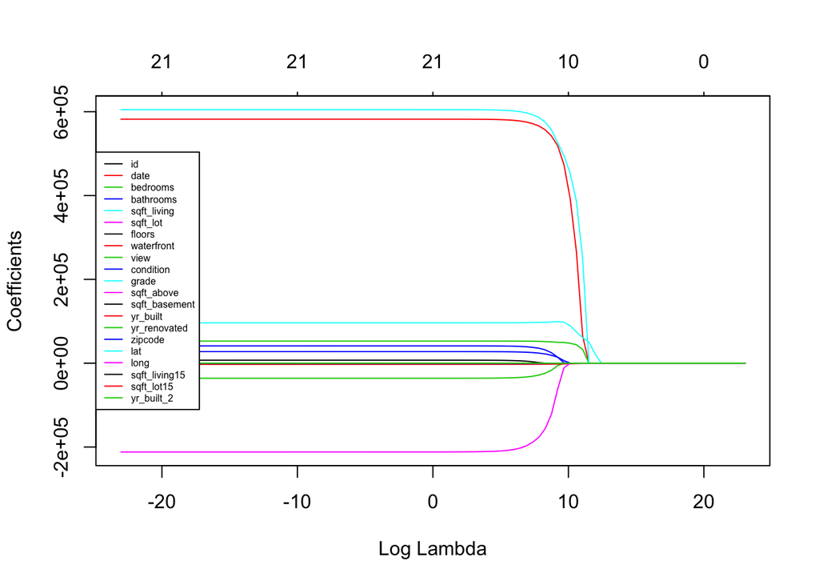

```r
# LASSO regression
cv_fit = cv.glmnet(x, y, alpha = 1, lambda = lambdas)
opt_lambda = cv_fit$lambda.min

model7 = cv_fit$glmnet.fit
plot(model7, xvar = "lambda")
legend("left", lwd = 1, col = 1:6, legend = colnames(x), cex = .5)
```

```r
# Elastic net regression
library(caret)
set.seed(111)
model8 = train(
  price ~., data = data, method = "glmnet",
  trControl = trainControl("cv", number = 10),
  tuneLength = 10
)

model8$bestTune
```

|  | alpha | lambda |
| --- | --- | --- |
| 94 | 1 | 1468.049 |

```r
# Stepwise regression
library(MASS)
model8 = lm(price~., data = data)
model8 = stepAIC(model8, direction = "both",
                      trace = FALSE)
summary(model8)
```

```
##
## Call:
## lm(formula = price ~ id + bedrooms + bathrooms + sqft_living +
##     sqft_lot + floors + waterfront + view + condition + grade +
##     sqft_above + yr_built + yr_renovated + zipcode + lat + long +
##     sqft_living15 + sqft_lot15 + yr_built_2, data = data)
##
## Residuals:
##      Min       1Q   Median       3Q      Max
## -1317688   -99197    -9464    76111  4340354
##
## Coefficients:
##                 Estimate Std. Error t value Pr(>|t|)
## (Intercept)    9.177e+07  7.674e+06  11.958  < 2e-16 ***
## id            -1.485e-06  4.812e-07  -3.086 0.002032 **
## bedrooms      -3.298e+04  1.900e+03 -17.358  < 2e-16 ***
## bathrooms      3.554e+04  3.276e+03  10.846  < 2e-16 ***
## sqft_living    1.510e+02  4.371e+00  34.537  < 2e-16 ***
## sqft_lot       1.244e-01  4.783e-02   2.601 0.009307 **
## floors        -1.376e+04  3.974e+03  -3.463 0.000536 ***
## waterfront     5.860e+05  1.730e+04  33.868  < 2e-16 ***
## view           5.474e+04  2.138e+03  25.599  < 2e-16 ***
## condition      3.053e+04  2.371e+03  12.876  < 2e-16 ***
## grade          9.579e+04  2.146e+03  44.640  < 2e-16 ***
## sqft_above     3.033e+01  4.346e+00   6.979 3.05e-12 ***
## yr_built      -8.830e+04  7.167e+03 -12.320  < 2e-16 ***
## yr_renovated   2.263e+01  3.652e+00   6.196 5.89e-10 ***
## zipcode       -6.053e+02  3.293e+01 -18.382  < 2e-16 ***
## lat            6.099e+05  1.072e+04  56.908  < 2e-16 ***
## long          -2.203e+05  1.312e+04 -16.785  < 2e-16 ***
## sqft_living15  2.175e+01  3.436e+00   6.330 2.51e-10 ***
## sqft_lot15    -3.518e-01  7.330e-02  -4.800 1.60e-06 ***
## yr_built_2     2.189e+01  1.831e+00  11.955  < 2e-16 ***
## ---
## Signif. codes:  0 '***' 0.001 '**' 0.01 '*' 0.05 '.' 0.1 ' ' 1
##
## Residual standard error: 200600 on 21593 degrees of freedom
## Multiple R-squared:  0.7018, Adjusted R-squared:  0.7016
## F-statistic:  2675 on 19 and 21593 DF,  p-value: < 2.2e-16
```